# IE 423 Project Part 1

Gulce Yavuz, Sercan Demirkilic, Baturalp Yalcin, Utku Atay

27 Ekim 2019

# Project 1

## Part 1

### 1) Reading the image

We had the foto in Jpg Format and read it with “readJPEG” command. Then, we checked the sizes of photo with “str”command. The size of the array is 512 x 512 x 3 which implies it is three dimensional.

```r
library(jpeg)
photo <- readJPEG("C:/Users/Lenovo/Desktop/photo3.jpg", native = FALSE) #reading the image
str(photo)
```

```
##  num [1:512, 1:512, 1:3] 0.851 0.855 0.859 0.855 0.855 ...
```

### 2) Plotting each channel

The structure of the variable that stores the image is a three dimensions array, which has the size 512 x 512 x 3 for dimensions. The photo consist of 3 different channels that represents the different colourlayers (red, green, blue) and each channel is a two dimensional array with 512 x 512 pixels. Actually, this is a Raster Image which has 512 pixels in vertical and horizontal dimensions, and the depth of the Raster Image shows the intensity of each color in the image.Combination of the each channels will create the original image.

We wrote a plot_image function to plot the three different channels of the image and the image itsels.We got the length of lines from 0.5 to 512.5 in plots because we wanted to see the corner and side parts clearly. This function will be useful in the following tasks of the project.

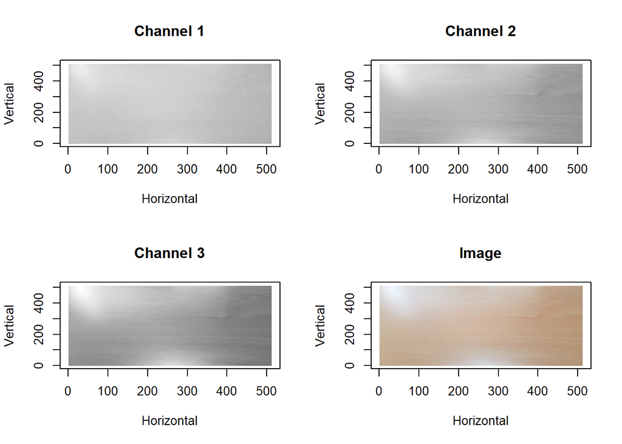

```r
plot_image <- function(image){
  par(mfrow=c(2,2))

  plot(0.5:512.5,0.5:512.5,type="n", xlab = "Horizontal", ylab = "Vertical", main = "Channel 1")
  rasterImage(image[,,1], 0.5,0.5, 512.5, 512.5,interpolate=FALSE) #plot first channel

  plot(0.5:512.5,0.5:512.5,type="n", xlab = "Horizontal", ylab = "Vertical", main = "Channel 2")
  rasterImage(image[,,2], 0.5,0.5, 512.5, 512.5,interpolate=FALSE) #plot second channel

  plot(0.5:512.5,0.5:512.5,type="n", xlab = "Horizontal", ylab = "Vertical", main = "Channel 3")
  rasterImage(image[,,3], 0.5,0.5, 512.5, 512.5,interpolate=FALSE) #plot third channel

  plot(0.5:512.5,0.5:512.5,type="n", xlab = "Horizontal", ylab = "Vertical", main = "Image")
  rasterImage(image, 0.5,0.5, 512.5, 512.5,interpolate=FALSE) #plot the the entire image
}

plot_image(photo)
```

### 3) Taking the column means and plotting them

For this part, we calculated the column means for each channel and plotted them with their color layers.

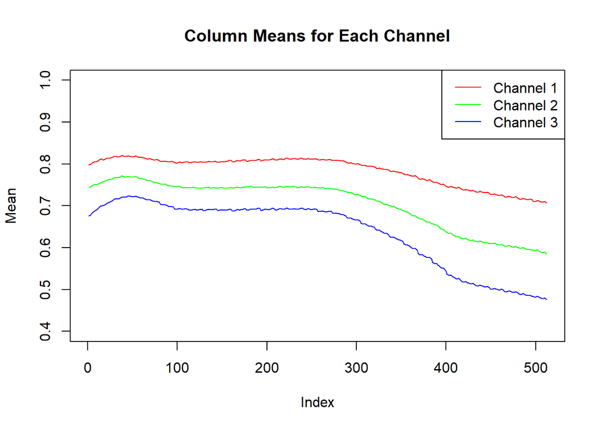

```r
column_means = colMeans(photo) #calculate the means of each columns
par(mfrow=c(1,1))
plot(column_means[,1], type = "l", col="red", main = "Column Means for Each Channel", ylab = "Mean", ylim = c(0.4,1))
lines(column_means[,2], col = "green")
lines(column_means[,3], col = "blue")
legend("topright", legend=c("Channel 1", "Channel 2", "Channel 3"), col=c("red","green", "blue"), lty=1, cex=1)
```

From the graph, we see that the red is the most intense color in each columns, and blue is the least intense color in each channel as well.

### 4) Subtracting one half of the image from the other half for each channel

We cropped the image vertically into two parts and substracted the second from the first half. Then, we plotted our new image and observed that the left part of the final image is darker. Because the image is similar in the both parts, their substraction will yield less intense colors, hence this will result in dark part on the left.

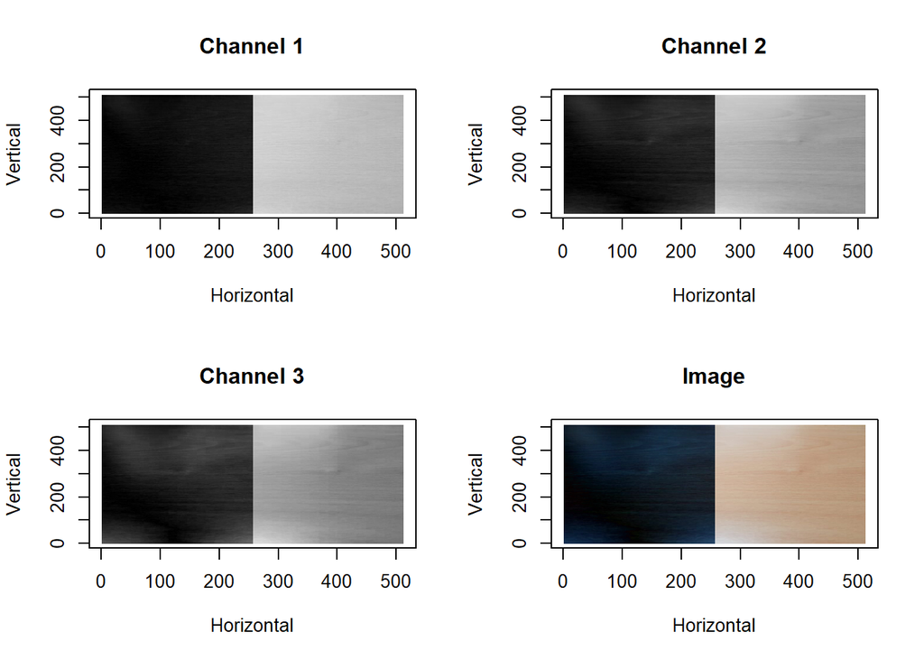

```r
crop_vertical <- function(image){
  half_l = length(image[,1,1])/2
  for(i in 1:(half_l)){
    image[,i,]= abs(image[,i,] - image[,(i+half_l),]) #substracting the second half from the first half
  }
  return(image)
}

photo_vertical=crop_vertical(photo)
plot_image(photo_vertical)
```

### 5) Median filtering

We wrote a function to apply median filtering, which makes replacing each entry with the median of neighboring entries. However, we can’t use median filtering for side and corner parts because the image doesn’t have enough pixels surrounding them. That’s why we added new zero columns and rows proportinal to window size. We had to create a temporary matrix to store median filtered values. Otherwise filtered values can be used during other pixels’ filtering process. Consequently, we used our function to apply median filtering with window sizes 5,11 and 31.

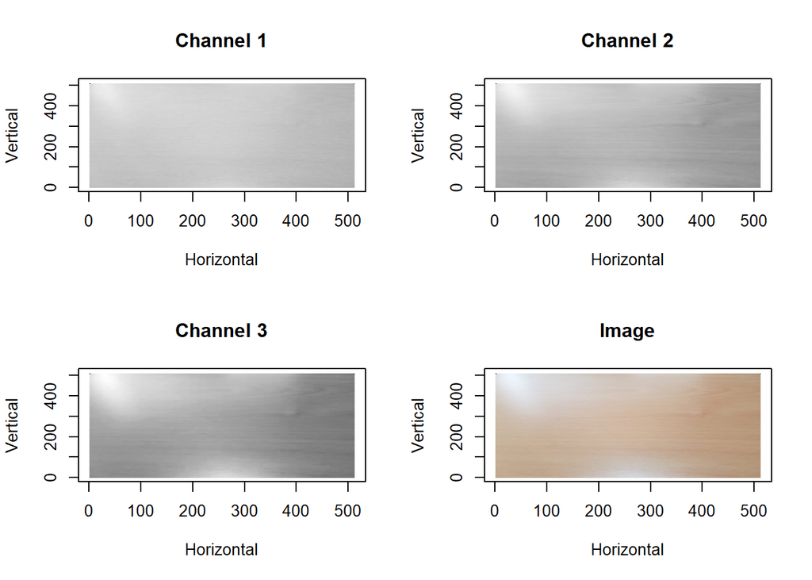

```r
median_filtering <- function(photo_matrix, window_size){
  #calculating the sizes to apply the function for all images
  matrix_size = length(photo_matrix[,1])
  half_up = (window_size+1)/2
  half_down = (window_size-1)/2
  #adding zeros to filter the corner parts of the image
  big_photo = matrix(0, ncol=matrix_size+window_size-1, nrow=matrix_size+window_size-1)
  big_photo[(half_up):(matrix_size+half_down),(half_up):(matrix_size+half_down)] = photo_matrix
  big_matrix_size = length(big_photo[,1])
  #temp_matrix to hold each median value for each window
  temp_matrix = matrix(0, ncol=matrix_size, nrow=matrix_size)

  for(i in 1:(big_matrix_size-window_size+1)){
    for(j in 1:(big_matrix_size-window_size+1)){
      part = big_photo[j:(j+window_size-1),i:(i+window_size-1)] #take the part of the window
      temp_matrix[j,i] = median(part) #hold the median value in respective cells in temp matrix
    }
  }
  return(temp_matrix) #return the median value matrix
}

channel_filtering <- function(image,window_size){ #function to filter all channels
  image[,,1] = median_filtering(image[,,1], window_size)
  image[,,2] = median_filtering(image[,,2], window_size)
  image[,,3] = median_filtering(image[,,3], window_size)
  return(image)
}

photo_filter_5=channel_filtering(photo, window_size = 5) #median_filtering with window size 5
plot_image(photo_filter_5)
```

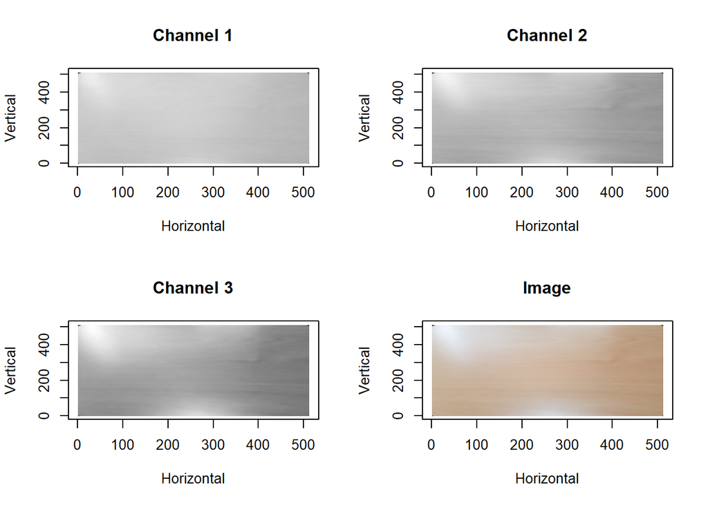

```r
photo_filter_11=channel_filtering(photo, window_size = 11) #median_filtering with window size 11
plot_image(photo_filter_11)
```

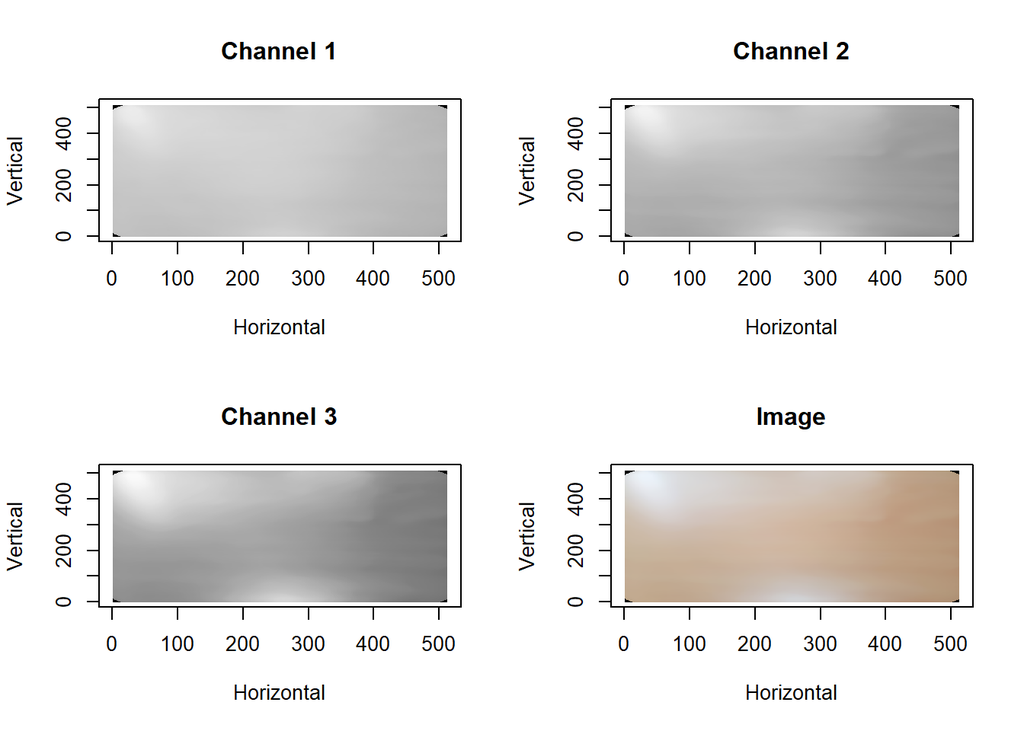

```r
photo_filter_31=channel_filtering(photo, window_size = 31) #median_filtering with window size 31
plot_image(photo_filter_31)
```

In order to compare the final results effectively, the final results are also plotted independently excluding the plots of the channels.

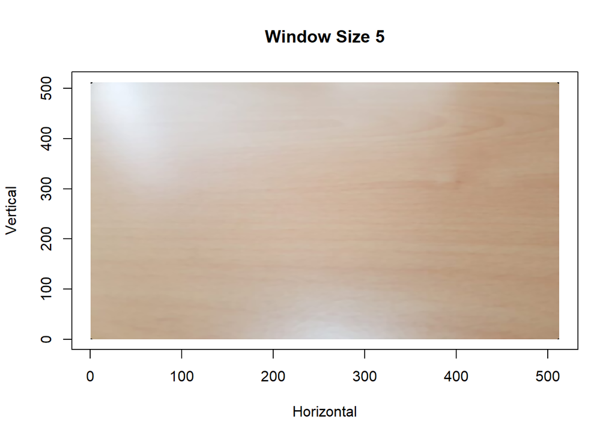

```r
plot(0.5:512.5,0.5:512.5,type="n", xlab = "Horizontal", ylab = "Vertical", main = "Window Size 5")
rasterImage(photo_filter_5, 0.5,0.5, 512.5, 512.5,interpolate=FALSE) #plot first channel
```

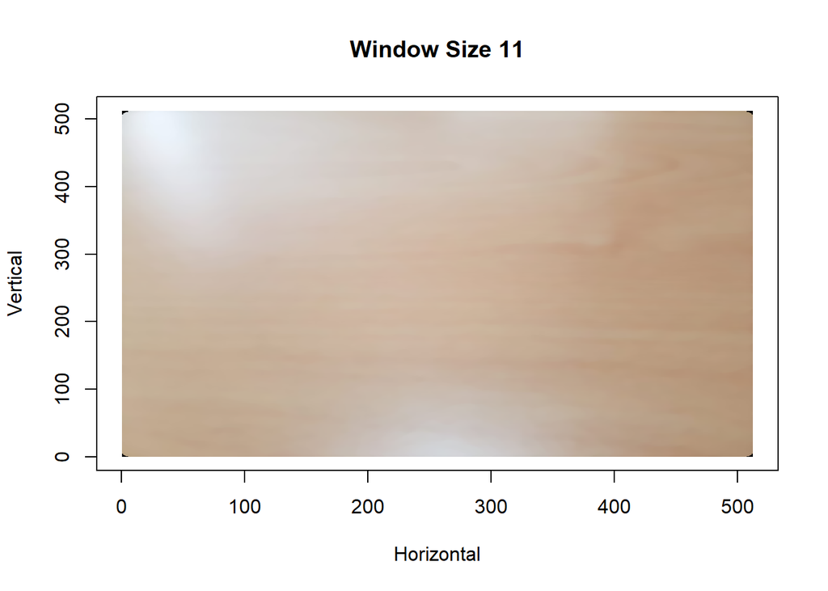

```r
plot(0.5:512.5,0.5:512.5,type="n", xlab = "Horizontal", ylab = "Vertical", main = "Window Size 11")
rasterImage(photo_filter_11, 0.5,0.5, 512.5, 512.5,interpolate=FALSE) #plot first channel
```

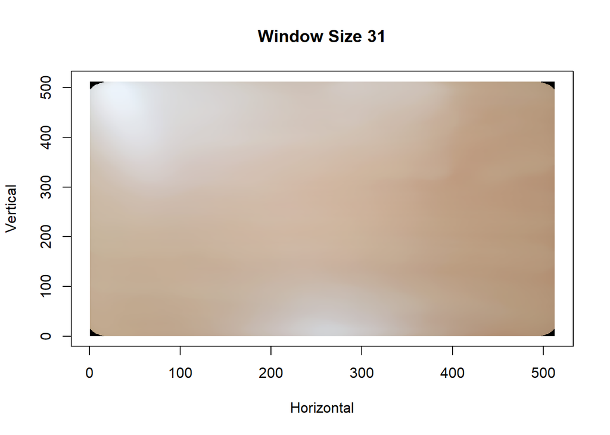

```r
plot(0.5:512.5,0.5:512.5,type="n", xlab = "Horizontal", ylab = "Vertical", main = "Window Size 31")
rasterImage(photo_filter_31, 0.5,0.5, 512.5, 512.5,interpolate=FALSE) #plot first channel
```

Median filtering is usually used to remove the defects or the noise from the images because it uses the information on the neighboring pixels of the each pixels. However, as the window size is increased, the median of the window will be unrelated to the value of the pixels in the middle because the farther the pixels are the more irrelevant the information is. As a result, as the window size is augmented, the images we obtain seem more blurry.

## PART 2

### 1) Plotting the histogram

In this part, we converted the image from colored one to grey scaled one by using image editors. We drew histogram with the pixel values. At the first view ,the distribution of pixels looks like a normal distribution.

```r
library(png)
par(mfrow=c(1,1))
photogs = readPNG("C:/Users/Lenovo/Desktop/photo3_gs.png") #read the greyscale image as 2D matrix
```

### 2) Finding distribution and calculating the mean and the standard deviation

we fit the distribution as a normal distribution with red line. Except for the some values on left of the mean, the red line fits good enough so that we can assume the distribution is normally distributed. Then, we calculated the mean and standard deviation values of this distribution.

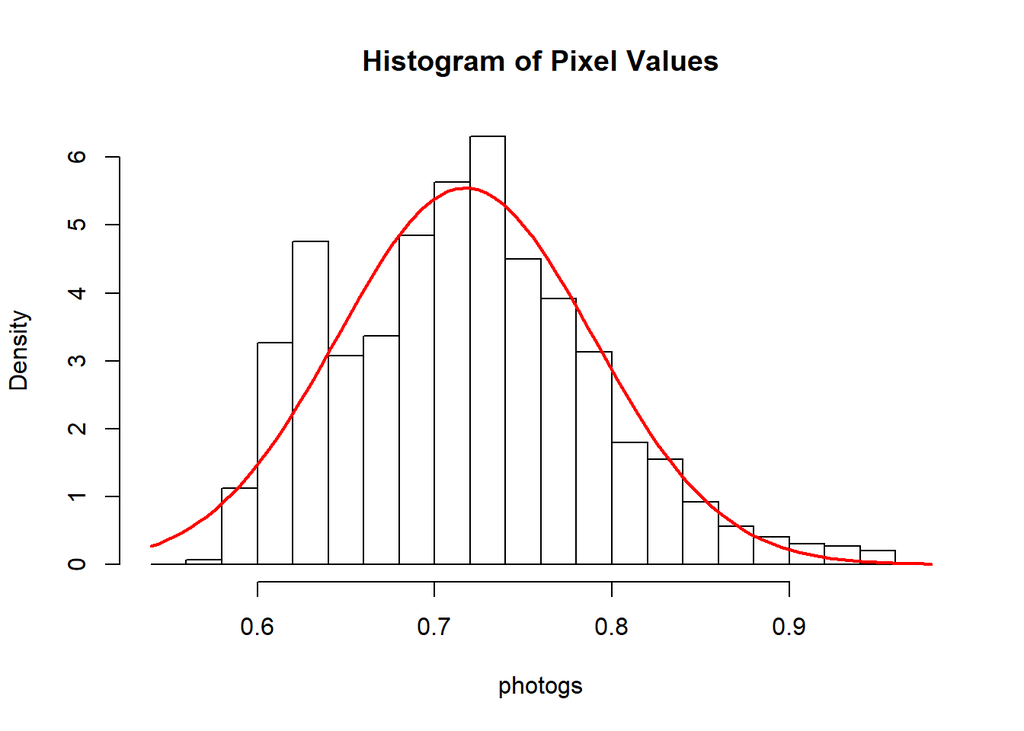

```r
library(MASS)
fit = fitdistr(photogs, densfun = "normal")
hist(photogs, pch=20, breaks=20, prob=TRUE, main="Histogram of Pixel Values")
curve(dnorm(x, fit$estimate[1], fit$estimate[2]), col="red", lwd=2, add=T)
```

```r
#Normal Distribution with Mean and SD
dist_mean = mean(photogs)
dist_sd = sd(photogs)
message("Pixel values are assumed to be distributed normally with mean ", round(dist_mean, digits = 3), " and standard deviation ", round(dist_sd, digits = 3), ".")
```

```
## Pixel values are assumed to be distributed normally with mean 0.717 and standard deviation 0.072.
```

The mean of the distribuion is 0.72 and the standard deviation is 0.072.

### 3) Finding pixels out of bounds (outliers)

Firstly, we calculate the lower bound and upper bound with significance level 0.001. The values that are located between those boundaries are classified acceptable and the others are called outliers. Therefore, we changed their values to zero, in other words made them black.

In the function, we created a binary matrix where the values are FALSE if the value is out of the bounds. If the pixel value is FALSE in the binary matrix, we converted the value into zero to make the pixel black.

```r
significance_level=0.001
#Upper and Lower Bounds Based on Normality Assumption
upper_bound = dist_mean + qnorm((1-significance_level/2))*dist_sd
lower_bound = dist_mean + qnorm(significance_level/2)*dist_sd
message("The lower bound is ", round(lower_bound, digits = 3), " and the upper bound is ", round(upper_bound, digits = 3), ".")
```

```
## The lower bound is 0.481 and the upper bound is 0.954.
```

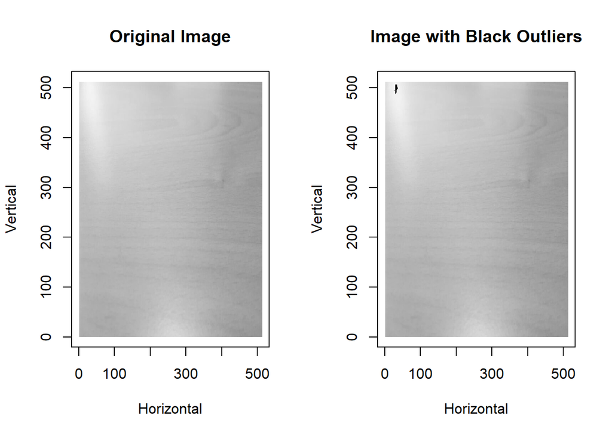

```r
#Detecting Outliers Based On LB&UB
detect_change_outliers <- function(photo, ub,lb){
  binary = (photo>=lb)&(photo<=ub) #binary matrix with FALSE values if it is outlier
  for(i in 1:length(photo[,1])){
    for(j in 1:length(photo[1,])){
      if(binary[i,j]==FALSE){
        photo[i,j]=0 #Change value to zero if outlier
      }
    }
  }
  return(photo)
}

photo_out = detect_change_outliers(photogs,upper_bound,lower_bound)
par(mfrow=c(1,2))
plot(0.5:512.5,0.5:512.5,type="n", main = "Original Image", xlab = "Horizontal", ylab = "Vertical")
rasterImage(photogs, 0.5,0.5, 512.5, 512.5,interpolate=FALSE)
plot(0.5:512.5,0.5:512.5,type="n", main="Image with Black Outliers", xlab = "Horizontal", ylab = "Vertical")
rasterImage(photo_out, 0.5,0.5, 512.5, 512.5,interpolate=FALSE)
```

In our image, due to the reflection, the outliers are located in top-left corner since in this region there is a fully white part where the values are not in our significance level.

### 4) Identifying the outliers in patches

In order to investigate our image process in a different way, we created a function which we give a patch size and a significance level. In this fuction, we are dividing the image into patches according to the patch size and find the outliers for patches separately. In each pathch, we assumed pixels have the same distribution as the in the full image. We calculated new mean and standard deviation values for each patch. Then, we detected the outliers according to the respective mean and standard deviation values.

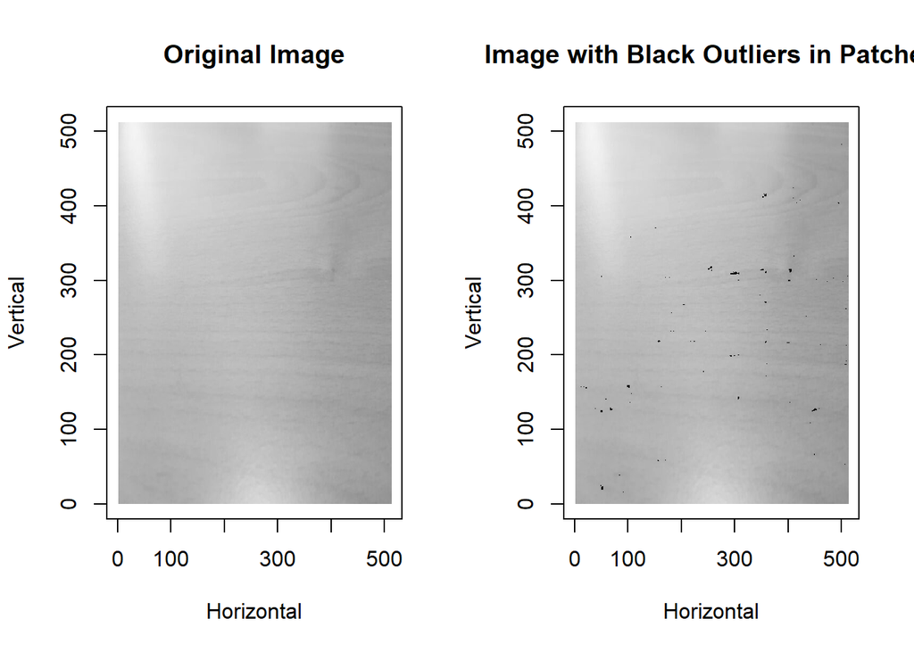

```r
patch_outliers <- function(photo, patch_size, significance_level){
  n_patches = floor(length(photo[,1])/patch_size) #Identify number of patches on each dimension
  for(i in 1:n_patches){
    for(j in 1:n_patches){
      patch = photo[((i-1)*patch_size+1):(i*patch_size),((j-1)*patch_size+1):(j*patch_size)] #take the patches
      dist_mean = mean(patch)
      dist_sd = sd(patch)
      upper_bound = dist_mean + qnorm((1-significance_level/2))*dist_sd
      lower_bound = dist_mean + qnorm(significance_level/2)*dist_sd
      patch=detect_change_outliers(patch,upper_bound,lower_bound) #identify the outliers in each patches by using the previous function
      photo[((i-1)*patch_size+1):(i*patch_size),((j-1)*patch_size+1):(j*patch_size)] = patch #change the patches with the new matrix
    }
  }
  return(photo)
}

photo_patches = patch_outliers(photogs,patch_size = 51,significance_level = 0.001)
par(mfrow=c(1,2))
plot(0.5:512.5,0.5:512.5,type="n", main = "Original Image", xlab = "Horizontal", ylab = "Vertical")
rasterImage(photogs, 0.5,0.5, 512.5, 512.5,interpolate=FALSE)
plot(0.5:512.5,0.5:512.5,type="n", main="Image with Black Outliers in Patches", xlab = "Horizontal", ylab = "Vertical")
rasterImage(photo_patches, 0.5,0.5, 512.5, 512.5,interpolate=FALSE)
```

In this process, we have significantly more outliers because we examine outliers within the each patch. When we find outliers in terms of patches, there might be some significant differences between pixels so outlier numbers are higher. However we have smaller numbers of outliers in full image because when we work with that high number of pixels, the values follow the distribution better.In other words, mean and variance represent the charachteristics of image more properly, so the number of outliers is decreasing.